# RR-assignment-1

## Define the questions

Note that the questions to be addressed were given in the [assignment] [1] and are included in the analysis sections below.  
[1]: [https://class.coursera.org/repdata-007/human_grading/view/courses/972596/assessments/3/submissions] “Assignment”

## Obtain the data

The data can be downloaded from the Course website [ https://d396qusza40orc.cloudfront.net/repdata%2Fdata%2Factivity.zip]  
or from the GitHub for the assignment [https://github.com/rdpeng/RepData_PeerAssessment1]

Note that that GitHub should be forked to a personal copy, then downloaded to a local git, and this is assumed to have been done.

```r
setwd("~/edu/IntroDataScience/5-RR/assignment1/RepData_PeerAssessment1")
library(lubridate)
colclass<- c("numeric","character","numeric")
rawdata<-read.csv("./activity.csv",header=TRUE,colClasses=colclass)
hhmm<-sprintf("%2.2f",rawdata[,3]/100)
sum(is.na(hhmm)) # confirm none are NA
```

```
## [1] 0
```

```r
ts<-ymd(rawdata[,2])+hm(hhmm)
rawdata<-cbind(rawdata,ts)
```

Note that rawdata contains three columns, steps, data and interval:  
* steps is the count of the number of steps in that time interval  
* date is read in as a charter string in ‘yyyy-mm-dd’ format * interval is the 5 minute time slice for the sample shown as 24H clock time but stored as an integer. Thus it is not a continuous variable, but jumps from (x)55 to(x+1)00 with no values between.

As read in, rawdata is a relatively small dataset with the size and range shown:

```r
object.size(rawdata)
```

```
## 495200 bytes
```

```r
summary(rawdata)
```

```
##      steps            date              interval
##  Min.   :  0.00   Length:17568       Min.   :   0.0
##  1st Qu.:  0.00   Class :character   1st Qu.: 588.8
##  Median :  0.00   Mode  :character   Median :1177.5
##  Mean   : 37.38                      Mean   :1177.5
##  3rd Qu.: 12.00                      3rd Qu.:1766.2
##  Max.   :806.00                      Max.   :2355.0
##  NA's   :2304
##        ts
##  Min.   :2012-10-01 00:00:00
##  1st Qu.:2012-10-16 05:58:45
##  Median :2012-10-31 11:57:30
##  Mean   :2012-10-31 11:57:30
##  3rd Qu.:2012-11-15 17:56:15
##  Max.   :2012-11-30 23:55:00
##
```

## Analysis

### Question 1. What is mean total number of steps taken per day?

**Question 1a**  
Make a histogram of the total number of steps taken each day.

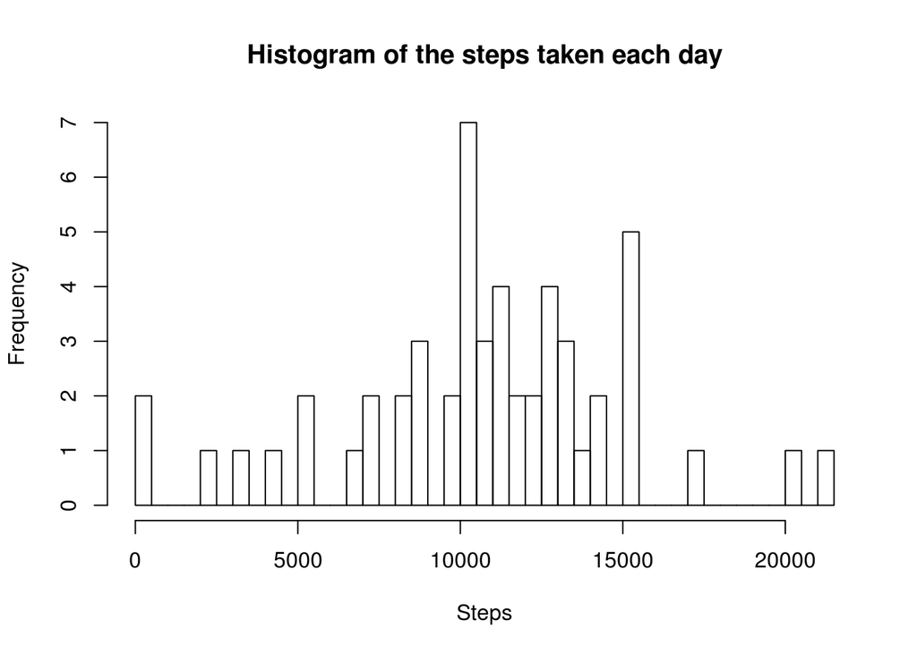

```r
daily<-aggregate(rawdata[,1]~rawdata[,2], FUN=sum)
daily<-cbind(daily,ymd(daily[,1]))
hist(daily[,2],length(daily[,2]),main="Histogram of the steps taken each day",xlab="Steps")
```

**Question 1b** Calculate and report the mean and median total number of steps taken per day.

```r
mean(daily[,2])
```

```
## [1] 10766.19
```

```r
median(daily[,2])
```

```
## [1] 10765
```

### Question 2. What is the average daily activity pattern?

**Question 2a**  
Make a time series plot (i.e. type = “l”) of the 5-minute interval (x-axis) and the average number of steps taken, averaged across all days (y-axis).

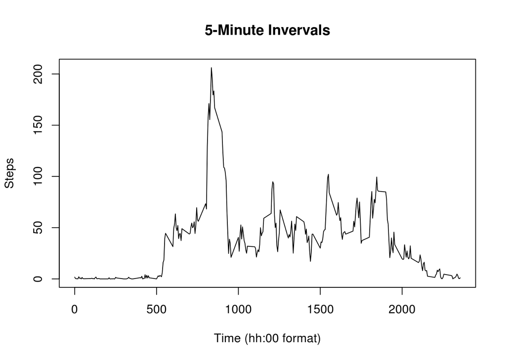

```r
interval<-aggregate(rawdata[,1]~rawdata[,3],FUN=mean)
plot(interval[,1],interval[,2],type="l",main="5-Minute Invervals",ylab="Steps",xlab="Time (hh:00 format)")
```

**Question 2b**  
Which 5-minute interval, on average across all the days in the dataset, contains the maximum number of steps?

This code finds the element with the maximum value, then looks up the time and value of the maximum, giving the result 835, or 8:35 AM.

```r
summary(interval[,2])
```

```
##    Min. 1st Qu.  Median    Mean 3rd Qu.    Max.
##   0.000   2.486  34.110  37.380  52.830 206.200
```

```r
maxat<-which.max(interval[,2])  # which interval number?
interval[maxat,1]  # which interval time ?
```

```
## [1] 835
```

```r
interval[maxat,2]  # what is the value?
```

```
## [1] 206.1698
```

### Question 3. Imputing missing values

**Question 3a**  
Calculate and report the total number of missing values in the dataset (i.e. the total number of rows with NAs).

```r
sum(is.na(rawdata[,1]))  # number of steps
```

```
## [1] 2304
```

```r
sum(is.na(rawdata[,2]))  # date
```

```
## [1] 0
```

```r
sum(is.na(rawdata[,3]))  # interval
```

```
## [1] 0
```

As can be seen from the sums above, only the number of steps variable has NA values, with a total of 2304 missing values.

**Question 3b**  
Devise a strategy for filling in all of the missing values in the dataset. The strategy does not need to be sophisticated. For example, you could use the mean/median for that day, or the mean for that 5-minute interval, etc.

First Confirm that all interval averages do contain valid data:

```r
sum(is.na(interval[,1]))  # intervals
```

```
## [1] 0
```

```r
sum(is.na(interval[,2]))  # average steps for the intervals
```

```
## [1] 0
```

Since every interval does have valid data, a simple strategy of replacing the missing interval value with the average for that interval will have all the necessary values.

**Question 3c**  
Create a new dataset that is equal to the original dataset but with the missing data filled in.

```r
cleandata<-rawdata                              # create the new dataset
for (i in 1:length(cleandata[,1])) {            # walk through each element
    if (is.na(cleandata[i,1])) {                #    look for NA value
        int2fix <- cleandata[i,3]               #       find the interval time
        intvalno <- interval[,1] == int2fix     #       find the data in the average interval table
        cleandata[i,1] <- interval[intvalno,2]  #       write the average value over the NA
    }
}
sum(is.na(cleandata[,1]))                       # confirm no more NA's
```

```
## [1] 0
```

**Question 3d**  
Make a histogram of the total number of steps taken each day and Calculate and report the mean and median total number of steps taken per day. Do these values differ from the estimates from the first part of the assignment? What is the impact of imputing missing data on the estimates of the total daily number of steps?

make the histogram as for Question 1a above

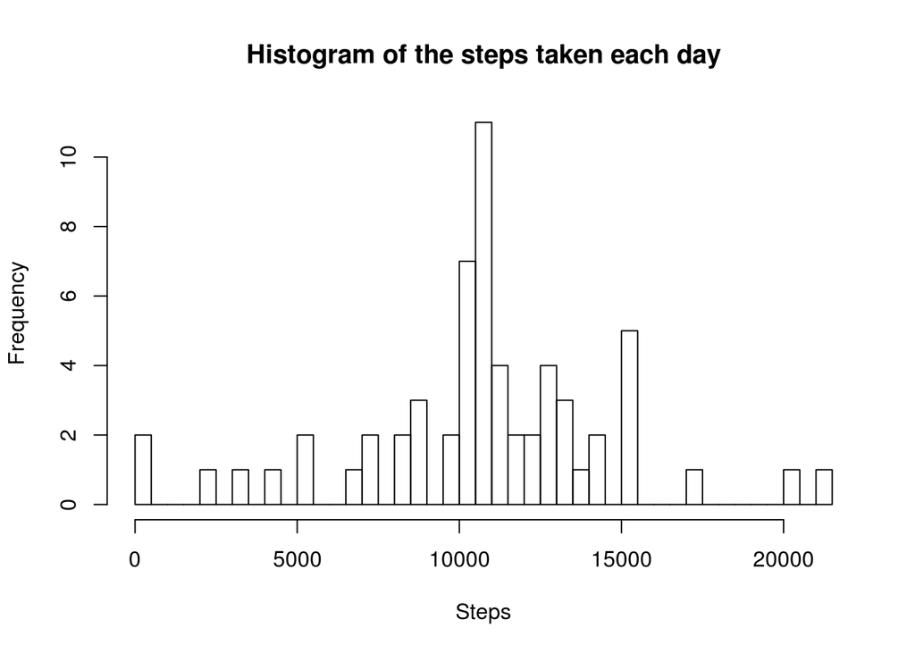

```r
daily<-aggregate(cleandata[,1]~cleandata[,2], FUN=sum)
daily<-cbind(daily,ymd(daily[,1]))
hist(daily[,2],length(daily[,2]),main="Histogram of the steps taken each day",xlab="Steps")
```

Calculate and report the mean and median total number of steps taken per day as was done for Question 1b above. Also show the summary data for the raw and clean data sets.

```r
mean(daily[,2])
```

```
## [1] 10766.19
```

```r
median(daily[,2])
```

```
## [1] 10766.19
```

```r
summary(rawdata[,1])
```

```
##    Min. 1st Qu.  Median    Mean 3rd Qu.    Max.    NA's
##    0.00    0.00    0.00   37.38   12.00  806.00    2304
```

```r
summary(cleandata[,1])
```

```
##    Min. 1st Qu.  Median    Mean 3rd Qu.    Max.
##    0.00    0.00    0.00   37.38   27.00  806.00
```

### uestion 4. Are there differences in activity patterns between weekdays and weekends?

For this part the weekdays() function may be of some help here. Use the dataset with the filled-in missing values for this part.

**Question 4a**  
Create a new factor variable in the dataset with two levels – “weekday” and “weekend” indicating whether a given date is a weekday or weekend day.

This code modifies the cleandata set to include a new factor variable (wkdef - WeeK Day or End Factor) with the values “Weekday” or “Weekend”, and displays summary information about it.

```r
wkday<-weekdays(cleandata$ts,TRUE)
wkde<-gsub("Mon|Tue|Wed|Thu|Fri","Weekday", wkday)
wkde<-gsub("Sun|Sat","Weekend", wkde)
wkdef<-as.factor(wkde)
cleandata<-cbind(cleandata,wkdef)
summary(cleandata)
```

```
##      steps            date              interval
##  Min.   :  0.00   Length:17568       Min.   :   0.0
##  1st Qu.:  0.00   Class :character   1st Qu.: 588.8
##  Median :  0.00   Mode  :character   Median :1177.5
##  Mean   : 37.38                      Mean   :1177.5
##  3rd Qu.: 27.00                      3rd Qu.:1766.2
##  Max.   :806.00                      Max.   :2355.0
##        ts                          wkdef
##  Min.   :2012-10-01 00:00:00   Weekday:12960
##  1st Qu.:2012-10-16 05:58:45   Weekend: 4608
##  Median :2012-10-31 11:57:30
##  Mean   :2012-10-31 11:57:30
##  3rd Qu.:2012-11-15 17:56:15
##  Max.   :2012-11-30 23:55:00
```

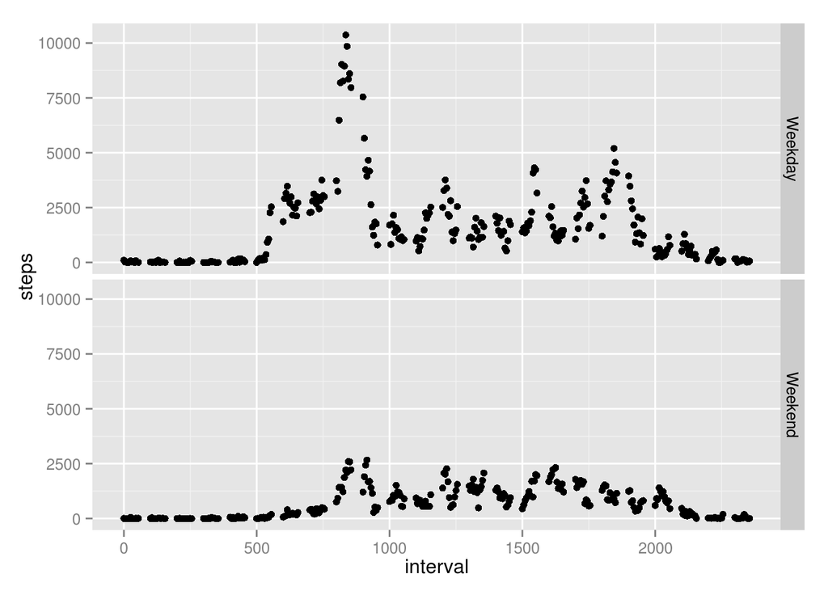

```r
library(ggplot2)
interval<-aggregate(cleandata[,1]~cleandata[,3]+cleandata[,5],FUN=sum)
names(interval)<-c("interval","wkdef","steps")
p<-qplot(interval,steps,data=interval,facets=wkdef~.)
print(p)
```